# trackname_textmining

Chanmi Yoo

2019 12 10

### Load library

```r
library(tidyverse)
library(data.table)
```

### Load Data

```r
setwd("C:/Users/Chanmi Yoo/Desktop/빅데/팀프로젝트/data")
spotify <- fread("SpotifyFeatures.csv", encoding = "UTF-8")
```

### 1) NA 값 확인

```r
table(is.na(spotify))
```

```
##
##   FALSE
## 4189050
```

[설명] 결측치가 전혀 없다.

### 2) 중복 음원 제거

```r
spotify.uniq <- spotify[-which(duplicated(spotify$track_id)),]
dim(spotify.uniq)
```

```
## [1] 176774     18
```

[설명] 총 176774개 음원이 있다.

## Creating Word Cloud - Track Title

### [가설] 노래 제목으로 가장 많이 나오는 단어는 love일 것이다.

### Load Library

```r
library(tm)
```

```r
library(wordcloud)
library(RColorBrewer)

# Expand memory limit
memory.limit(9999999999999)
```

```
## [1] 1e+13
```

### Create text1 vector

데이터가 너무 커서 단어를 추출하는 데 시간이 오래 소요된다. 그래서 text11(60000개), text12(60000개), text13(56774개), 3등분하여 Corpus를 처리하였다.

```r
text1 <- spotify.uniq %>%
  mutate(rank=row_number(desc(popularity))) %>%
  filter(rank %in% 1:60000) %>%
  select(track_name)

text2 <- spotify.uniq %>%
  mutate(rank=row_number(desc(popularity))) %>%
  filter(rank %in% 60001:120000) %>%
  select(track_name)

text3 <- spotify.uniq %>%
  mutate(rank=row_number(desc(popularity))) %>%
  filter(rank %in% 120001:176774) %>%
  select(track_name)

# 노래 제목이 아닌 단어를 제거
# 1) featuring 정보 제거
# 어떠한 형태로 되어 있는지 확인: tail(str_subset(get(paste("text", i, sep=""))$track_name, regex('feat', ignore_case = T)), 10)
## [설명] featuring 정보는 대부분 "(feat. [가수])", "(Feat. [가수])", "[FEAT. [가수]]"의 형태로 들어간다.
text1 <-  text1 %>%
  str_replace("[[:blank:]]{1}[fF]{1}(eat)[[:print:]]+", "") %>%
  str_replace_all("[[:blank:]]{1}(FEAT.)[[:print:]]+", "")
# 2) remaster 정보 제거
#tail(str_subset(text1, regex('remaster', ignore_case = T)), 10)
## [설명] remastered 정보는 대부분 "- Remastered" " - Remasterizado [연도]" 의 형태로 들어간다.
text1 <- text1 %>%
  str_replace_all("(Remastered) +", "") %>%
  str_replace_all("[0-9]{4}[[:space:]]{1}(Remaster)", "") %>%
  str_replace_all("(-)[[:space:]]{1}(Remasterizado)[[:space:]]{1}[0-9]{4}", "") %>%
  str_replace_all("(- Remastered)", "") %>%
  str_replace_all("(Remastered)", "") %>%
  str_replace_all("(- Remaster)", "") %>%
  str_replace_all("[0-9]{4}[[:print:]](Remaster)", "") %>%
  str_replace_all("[0-9]{4}( Digital Remaster)+", "") %>%
  str_replace_all("[-(]{1}[[:print:]]+", "")

# 3) version 정보 제거
#tail(str_subset(text1$track_name, regex('version', ignore_case = T)), 10)
## [설명] version 정보는 " - [문자] Version " 혹은 " ( [문자] version ) 의 형태로 들어간다.
text1 <- text1 %>%
  str_replace_all("(-)[[:space:]][[:print:]]+[Vv]{1}(ersion)", "") %>%
  str_replace_all("(- Version)", "") %>%
  str_replace_all("(()[[:print:]][Vv]{1}(ersion)())", "")

# create a corpus
#docs <- Corpus(VectorSource(get(paste("text", i, sep=""))))
docs1 <- Corpus(VectorSource(text1))

# clean text1 data
docs1 <- docs1 %>%
  tm_map(removePunctuation) %>%  # 구두점 제거
  tm_map(stripWhitespace) %>%  # 빈 띄어쓰기 제거
  tm_map(content_transformer(tolower)) %>%  # 소문자화
  tm_map(removeWords, c(stopwords("english"), 'dont', 'cant')) # 불용어 제거(english 패키지, 'dont' 'cant'는 en만 불용어로 설정하고 워드클라우드를 만들었더니 의미없는 단어가 몇 개 나와서 자발적으로 추가한 불용어임.)
# create a document-term-matrix
dtm1 <- TermDocumentMatrix(docs1)
matrix1 <- as.matrix(dtm1)

words1 <- sort(rowSums(matrix1), decreasing = T)
df1 <- data.frame(word = names(words1), freq1 = words1)
```

동일한 방식으로 Text2와 Text3를 처리했다.

```r
# Text2 처리
text2$track_name <-  text2$track_name %>%
  # 1) featuring 정보 제거
  str_replace("[[:blank:]]{1}[fF]{1}(eat)[[:print:]]+", "") %>%
  str_replace_all("[[:blank:]]{1}(FEAT.)[[:print:]]+", "") %>%
  # 2) remaster 정보 제거
  str_replace_all("(Remastered) +", "") %>%
  str_replace_all("[0-9]{4}[[:space:]]{1}(Remaster)", "") %>%
  str_replace_all("(-)[[:space:]]{1}(Remasterizado)[[:space:]]{1}[0-9]{4}", "") %>%
  str_replace_all("(- Remastered)", "") %>%
  str_replace_all("(Remastered)", "") %>%
  str_replace_all("(- Remaster)", "") %>%
  str_replace_all("[0-9]{4}[[:print:]](Remaster)", "") %>%
  str_replace_all("[0-9]{4}( Digital Remaster)+", "") %>%
  str_replace_all("[-(]{1}[[:print:]]+", "") %>%
  # 3) version 정보
  str_replace_all("(-)[[:space:]][[:print:]]+[Vv]{1}(ersion)", "") %>%
  str_replace_all("(- Version)", "") %>%
  str_replace_all("(()[[:print:]][Vv]{1}(ersion)())", "")

# Create a corpus
docs2 <- Corpus(VectorSource(text2))%>%
  # Cleane text2 data
  tm_map(removePunctuation) %>%
  tm_map(stripWhitespace) %>%
  tm_map(content_transformer(tolower)) %>%
  tm_map(removeWords, c(stopwords("english"), 'dont', 'cant'))
# Create a document-term-matrix
dtm2 <- TermDocumentMatrix(docs2)
matrix2 <- as.matrix(dtm2)

words2 <- sort(rowSums(matrix2), decreasing = T)
df2 <- data.frame(word = names(words2), freq2 = words2)


# Text3 처리
text3$track_name <-  text3$track_name %>%
  # 1) featuring 정보 제거
  str_replace("[[:blank:]]{1}[fF]{1}(eat)[[:print:]]+", "") %>%
  str_replace_all("[[:blank:]]{1}(FEAT.)[[:print:]]+", "") %>%
  # 2) remaster 정보 제거
  str_replace_all("(Remastered) +", "") %>%
  str_replace_all("[0-9]{4}[[:space:]]{1}(Remaster)", "") %>%
  str_replace_all("(-)[[:space:]]{1}(Remasterizado)[[:space:]]{1}[0-9]{4}", "") %>%
  str_replace_all("(- Remastered)", "") %>%
  str_replace_all("(Remastered)", "") %>%
  str_replace_all("(- Remaster)", "") %>%
  str_replace_all("[0-9]{4}[[:print:]](Remaster)", "") %>%
  str_replace_all("[0-9]{4}( Digital Remaster)+", "") %>%
  str_replace_all("[-(]{1}[[:print:]]+", "") %>%
  # 3) version 정보
  str_replace_all("(-)[[:space:]][[:print:]]+[Vv]{1}(ersion)", "") %>%
  str_replace_all("(- Version)", "") %>%
  str_replace_all("(()[[:print:]][Vv]{1}(ersion)())", "")

# Create a corpus
docs3 <- Corpus(VectorSource(text3))%>%
  # Cleane text2 data
  tm_map(removePunctuation) %>%
  tm_map(stripWhitespace) %>%
  tm_map(content_transformer(tolower)) %>%
  tm_map(removeWords, c(stopwords("english"), 'dont', 'cant'))
# Create a document-term-matrix
dtm3 <- TermDocumentMatrix(docs3)
matrix3 <- as.matrix(dtm3)

words3 <- sort(rowSums(matrix3), decreasing = T)
df3 <- data.frame(word = names(words3), freq3 = words3)
```

### df1, df2, df3 합치기

```r
df1$word <- as.character(df1$word)
df2$word <- as.character(df2$word)
df3$word <- as.character(df3$word)

df <- full_join(df1, df2, by="word") %>%
  full_join(df3, by="word")

df <- df %>%
  mutate(freq = rowSums(subset(df, select=c(freq1,freq2,freq3)), na.rm = T)) %>%
  select(word, freq) %>%
  arrange(desc(freq))
```

### 빈도수가 높은 상위 10개 단어

```r
head(df,10)
```

```
##      word freq
## 1     act 4037
## 2    love 2922
## 3   major 1349
## 4   minor 1283
## 5     one 1079
## 6    song  992
## 7     iii  987
## 8    time  950
## 9  little  887
## 10    man  836
```

[결과] act(4037회)로 가장 많았고, love(2922회)가 그 뒤를 이었으며, major, minor, one, song 순으로 많았다. [추가설명] 클래식 음악의 경우, 노래제목이 Beethoven: Symphony No.9 in D minor Op. 125 ‘Choral’ 와 같은 형식으로 표현된다. 베토벤 교향곡 제 9번 라단조 작품번호 125번 합창이라는 의미이다. 따라서 major, minor, iii 등을 불용어라 보기 어렵다고 판단하여 추가하지 않았다.

### Draw wordcloud

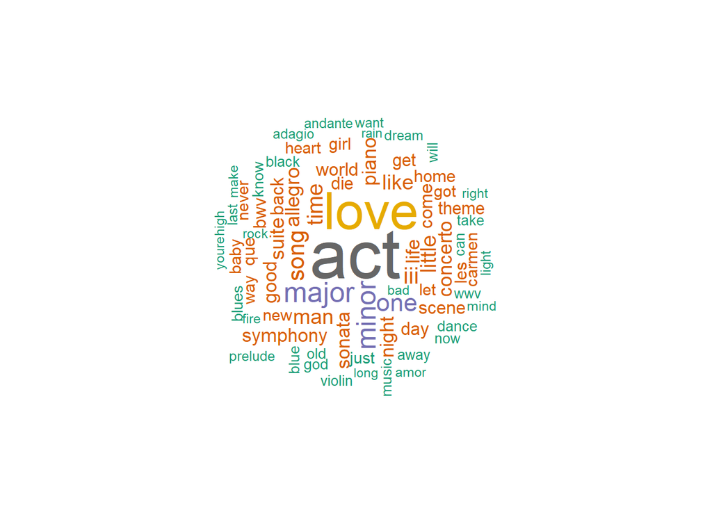

```r
set.seed(1234) # for reproducibility
wordcloud(words = df$word, freq = df$freq,
          min.freq = 300, # 최소 300번 이상 나온 단어 추출
          random.order=FALSE, rot.per=0.35,
          colors=brewer.pal(8, "Dark2"))
```

[결과] act(4037회)로 가장 많은 이유는 행동을 의미하는 act와 악장을 의미하는 act가 합쳐졌기 때문으로 보인다.

## Sentiment Analysis

### [가설] 노래 제목에는 어떤 부정단어, 긍정단어가 많이 나올까?

### Load Dictionary

```r
library(tidytext)
## tidytext 패키지에 내장된 "bing" 감성어 사전(부정/긍정 2가지로 구분) 이용
```

```r
df_word_counts <- df %>%
  inner_join(get_sentiments("bing"), by='word')

table(df_word_counts$sentiment)
```

```
##
## negative positive
##     1539      752
```

[설명] 부정단어(1539개)가 긍정단어(752개)보다 많다.

### 상위 20개 부정단어/긍정단어 시각화

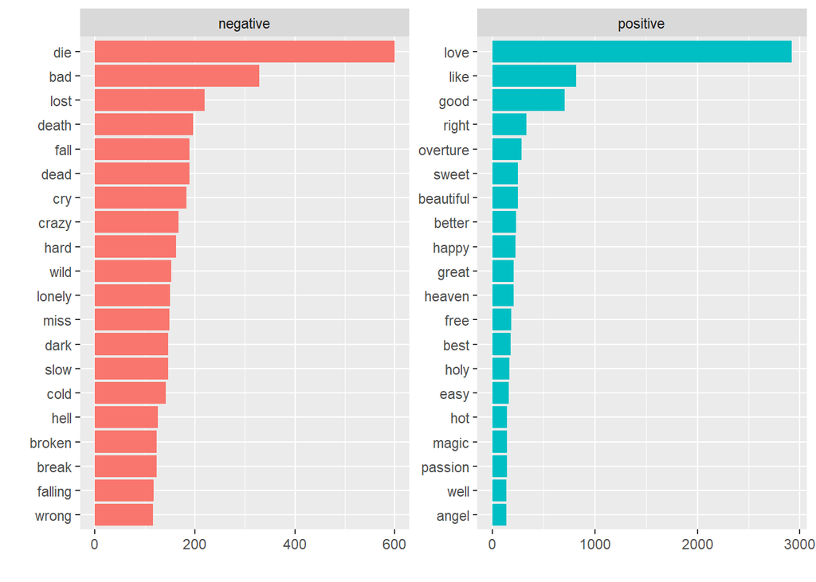

```r
top_words <- df_word_counts %>%
  group_by(sentiment) %>%
  top_n(20, freq) %>%
  ungroup() %>%
  mutate(word=reorder(word,freq))

library(ggplot2)
ggplot(top_words, aes(word, freq, fill=sentiment))+
  geom_col(show.legend = F)+
  facet_wrap(~sentiment, scales = 'free')+
  coord_flip()+
  labs(x="", y="")
```

[결론] 노래 제목에 나오는 부정어로는 die가 1위로 두드러지게 많았고, 그 뒤를 bad, lost, death, fall, dead가 이었다. 죽음, 이별과 관련된 단어가 많았다. 한편 긍정단어 중 가장 많이 나온 것은 love였으며, 그 뒤를 like, good, right, overture가 이었다. 여기서 overture는 ’서곡’으로 클래식 노래 제목으로 자주 들어가는 단어라 포함된 것으로 보인다. 긍정단어는 사랑, 아름다움, 자유 등 부정단어보다 다양한 양상의 표현이 보였다.